# Supervised Learning : Characterizing Life Expectancy Drivers Across Countries Using Model-Agnostic Interpretation Methods for Black-Box Models

#### 1.3.3.4 Linear Dependencies

**Code Chunk | Output**

```r
##################################
# Linear Dependencies
##################################

##################################
# Finding linear dependencies
##################################
DPA_LinearlyDependent <- findLinearCombos(DPA.Predictors.Numeric)

##################################
# Identifying the linearly dependent variables
##################################
DPA_LinearlyDependent <- findLinearCombos(DPA.Predictors.Numeric)

(DPA_LinearlyDependentCount <- length(DPA_LinearlyDependent$linearCombos))
```

```
## [1] 0
```

```r
if (DPA_LinearlyDependentCount == 0) {
  print("No linearly dependent predictors noted.")
} else {
  print(paste0("Linear dependency observed for ",
               (DPA_LinearlyDependentCount),
               " subset(s) of numeric variable(s)."))

  for (i in 1:DPA_LinearlyDependentCount) {
    DPA_LinearlyDependentSubset <- colnames(DPA.Predictors.Numeric)[DPA_LinearlyDependent$linearCombos[[i]]]
    print(paste0("Linear dependent variable(s) for subset ",
                 i,
                 " include: ",
                 DPA_LinearlyDependentSubset))
  }

}
```

```
## [1] "No linearly dependent predictors noted."
```

```r
##################################
# Identifying the linearly dependent variables for removal
##################################

if (DPA_LinearlyDependentCount > 0) {
  DPA_LinearlyDependent <- findLinearCombos(DPA.Predictors.Numeric)

  DPA_LinearlyDependentForRemoval <- length(DPA_LinearlyDependent$remove)

  print(paste0("Linear dependency can be resolved by removing ",
               (DPA_LinearlyDependentForRemoval),
               " numeric variable(s)."))

  for (j in 1:DPA_LinearlyDependentForRemoval) {
  DPA_LinearlyDependentRemovedVariable <- colnames(DPA.Predictors.Numeric)[DPA_LinearlyDependent$remove[j]]
  print(paste0("Variable ",
               j,
               " for removal: ",
               DPA_LinearlyDependentRemovedVariable))
  }

}
```

#### 1.3.3.5 Shape Transformation

**Code Chunk | Output**

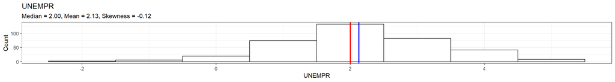

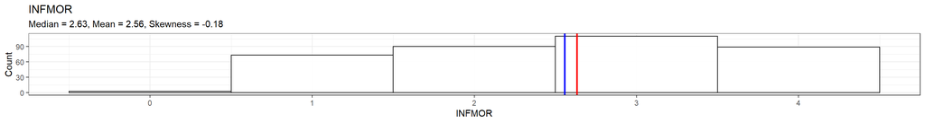

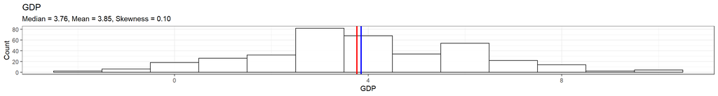

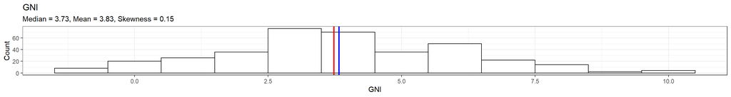

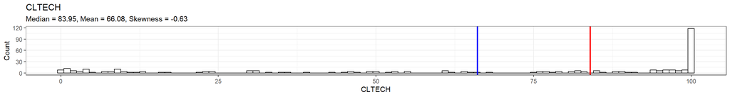

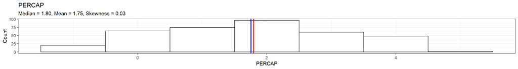

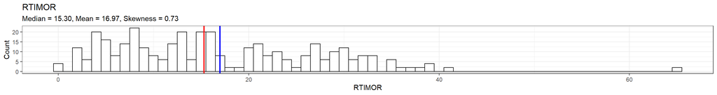

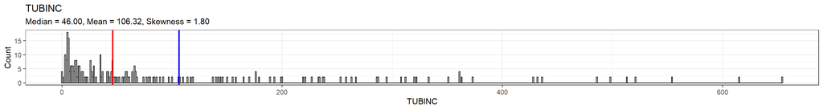

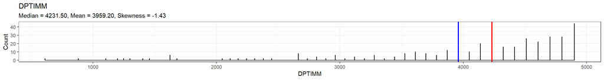

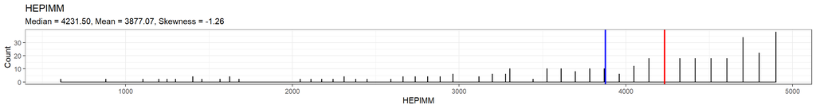

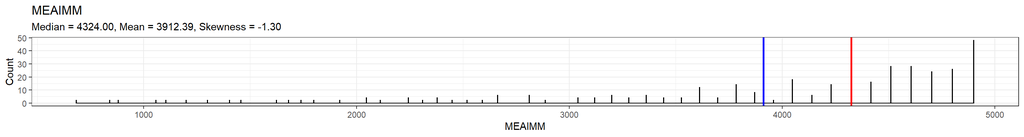

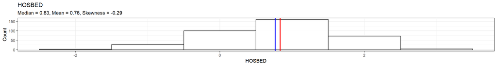

[6 more figures not shown]

```r
##################################
# Shape Transformation
##################################

##################################
# Applying a Box-Cox transformation
##################################
DPA_BoxCox <- preProcess(DPA.Predictors.Numeric, method = c("BoxCox"))
DPA_BoxCoxTransformed <- predict(DPA_BoxCox, DPA.Predictors.Numeric)

for (i in 1:ncol(DPA_BoxCoxTransformed)) {
  Median <- format(round(median(DPA_BoxCoxTransformed[,i],na.rm = TRUE),2), nsmall=2)
  Mean <- format(round(mean(DPA_BoxCoxTransformed[,i],na.rm = TRUE),2), nsmall=2)
  Skewness <- format(round(skewness(DPA_BoxCoxTransformed[,i],na.rm = TRUE),2), nsmall=2)
  print(
  ggplot(DPA_BoxCoxTransformed, aes(x=DPA_BoxCoxTransformed[,i])) +
  geom_histogram(binwidth=1,color="black", fill="white") +
  geom_vline(aes(xintercept=mean(DPA_BoxCoxTransformed[,i])),
            color="blue", size=1) +
    geom_vline(aes(xintercept=median(DPA_BoxCoxTransformed[,i])),
            color="red", size=1) +
  theme_bw() +
  ylab("Count") +
  xlab(names(DPA_BoxCoxTransformed)[i]) +
  labs(title=names(DPA_BoxCoxTransformed)[i],
       subtitle=paste0("Median = ", Median,
                       ", Mean = ", Mean,
                       ", Skewness = ", Skewness)))
}
```

```r
DPA_BoxCoxTransformed <- cbind(DPA_BoxCoxTransformed,DPA[,c("COUNTRY",
                                                            "YEAR",
                                                            "GENDER",
                                                            "CONTIN",
                                                            "LIFEXP")])
```

#### 1.3.3.6 Pre-Processed Dataset

**Code Chunk | Output**

```r
##################################
# Creating the pre-modelling
# train set
##################################
PMA <- DPA_BoxCoxTransformed[,!names(DPA_BoxCoxTransformed) %in% c("YEAR",
                                                                   "GNI",
                                                                   "DPTIMM",
                                                                   "MEAIMM",
                                                                   "RURPOP",
                                                                   "SANSER",
                                                                   "RTIMOR")]

##################################
# Gathering descriptive statistics
##################################
(PMA_Skimmed <- skim(PMA))
```

Data summary

| Name | PMA |
| --- | --- |
| Number of rows | 364 |
| Number of columns | 16 |
| _______________________ |  |
| Column type frequency: |  |
| character | 1 |
| factor | 2 |
| numeric | 13 |
| ________________________ |  |
| Group variables | None |

**Variable type: character**

| skim_variable | n_missing | complete_rate | min | max | empty | n_unique | whitespace |
| --- | --- | --- | --- | --- | --- | --- | --- |
| COUNTRY | 0 | 1 | 4 | 30 | 0 | 182 | 0 |

**Variable type: factor**

| skim_variable | n_missing | complete_rate | ordered | n_unique | top_counts |
| --- | --- | --- | --- | --- | --- |
| GENDER | 0 | 1 | FALSE | 2 | Mal: 182, Fem: 182 |
| CONTIN | 0 | 1 | FALSE | 6 | Afr: 106, Asi: 94, Eur: 78, Nor: 42 |

**Variable type: numeric**

| skim_variable | n_missing | complete_rate | mean | sd | p0 | p25 | p50 | p75 | p100 | hist |
| --- | --- | --- | --- | --- | --- | --- | --- | --- | --- | --- |
| UNEMPR | 0 | 1 | 2.13 | 1.21 | -2.05 | 1.42 | 2.00 | 2.90 | 5.26 | ▁▂▇▅▂ |
| INFMOR | 0 | 1 | 2.56 | 1.06 | 0.34 | 1.70 | 2.63 | 3.49 | 4.49 | ▅▆▇▇▆ |
| GDP | 0 | 1 | 3.85 | 2.21 | -1.67 | 2.55 | 3.76 | 5.53 | 9.97 | ▂▇▇▆▁ |
| CLTECH | 0 | 1 | 66.08 | 37.77 | 0.00 | 30.30 | 83.95 | 100.00 | 100.00 | ▃▁▁▂▇ |
| PERCAP | 0 | 1 | 1.75 | 1.40 | -1.48 | 0.65 | 1.80 | 2.82 | 4.73 | ▂▆▇▆▃ |
| TUBINC | 0 | 1 | 106.32 | 137.70 | 0.00 | 12.00 | 46.00 | 150.00 | 654.00 | ▇▂▁▁▁ |
| HEPIMM | 0 | 1 | 3877.07 | 1006.71 | 612.00 | 3304.98 | 4231.50 | 4704.00 | 4900.00 | ▁▁▁▃▇ |
| HOSBED | 0 | 1 | 0.76 | 0.86 | -1.61 | 0.14 | 0.83 | 1.40 | 2.62 | ▁▅▇▇▃ |
| TUBTRT | 0 | 1 | 77.92 | 17.31 | 0.00 | 73.00 | 83.00 | 88.00 | 100.00 | ▁▁▁▅▇ |
| URBPOP | 0 | 1 | 58.27 | 22.68 | 13.25 | 40.24 | 58.36 | 77.38 | 100.00 | ▅▆▇▇▅ |
| NCOMOR | 0 | 1 | 4.67 | 1.08 | 1.87 | 3.93 | 4.72 | 5.38 | 7.96 | ▂▅▇▃▁ |
| SUIRAT | 0 | 1 | 9.49 | 10.91 | 0.00 | 3.18 | 6.25 | 11.80 | 116.00 | ▇▁▁▁▁ |
| LIFEXP | 0 | 1 | 72.50 | 7.77 | 51.20 | 66.93 | 73.53 | 78.54 | 87.45 | ▁▃▆▇▅ |

### 1.3.4 Data Exploration

**Code Chunk | Output**

```r
##################################
# Loading dataset
##################################
PME <- PMA
PME.Numeric <- PME[,sapply(PME, is.numeric), drop = FALSE]

##################################
# Listing all Predictors
##################################
PME.Predictors <- PME[,!names(PME) %in% c("COUNTRY","LIFEXP")]

##################################
# Listing all numeric Predictors
##################################
PME.Predictors.Numeric <- PME.Predictors[,sapply(PME.Predictors, is.numeric), drop = FALSE]
ncol(PME.Predictors.Numeric)
```

```
## [1] 12
```

```r
##################################
# Listing all numeric Predictors
##################################
PME.Predictors.Factor <- PME.Predictors[,sapply(PME.Predictors, is.factor), drop = FALSE]
ncol(PME.Predictors.Factor)
```

```
## [1] 2
```

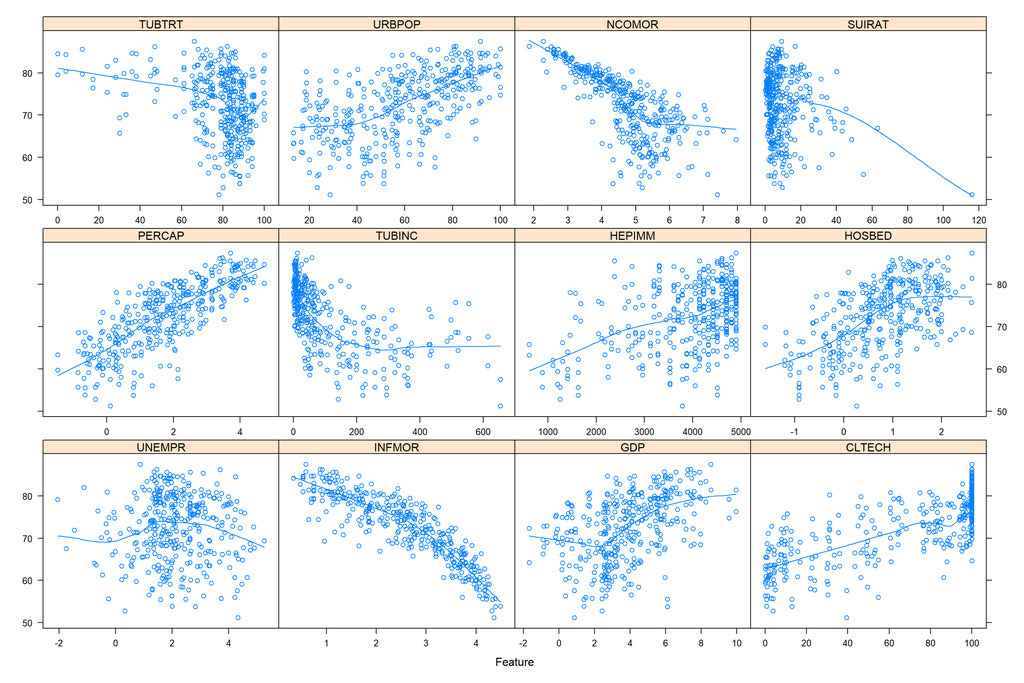

```r
##################################
# Formulating the scatter plot
##################################
featurePlot(x = PME.Predictors.Numeric,
            y = PME$LIFEXP,
            plot = "scatter",
            type = c("p", "smooth"),
            span = .5,
            layout = c(4, 3))
```

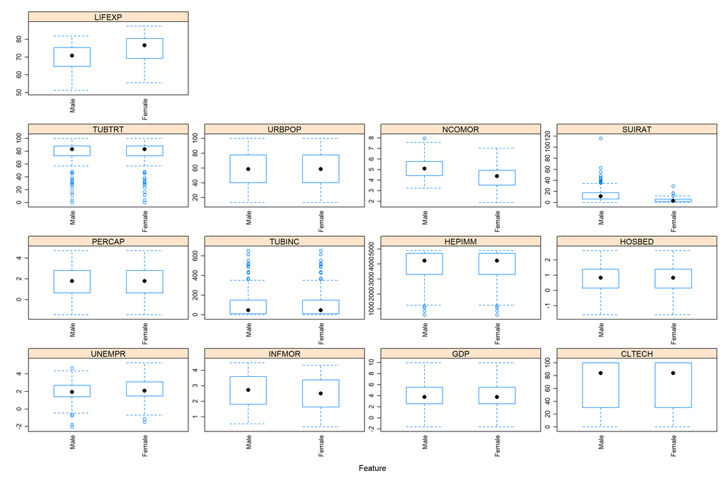

```r
##################################
# Formulating the box plot
##################################
featurePlot(x = PME.Numeric,
            y = PME$GENDER,
            plot = "box",
            scales = list(x = list(relation="free", rot = 90),
                          y = list(relation="free")),
            adjust = 1.5,
            layout = c(4, 4))
```

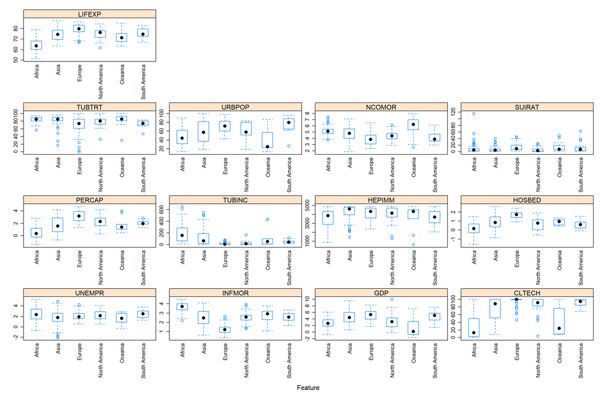

```r
##################################
# Formulating the box plot
##################################
featurePlot(x = PME.Numeric,
            y = PME$CONTIN,
            plot = "box",
            scales = list(x = list(relation="free", rot = 90),
                          y = list(relation="free")),
            adjust = 1.5,
            layout = c(4, 4))
```

### 1.3.5 Feature Selection

#### 1.3.5.1 Locally Weighted Scatterplot Smoothing Pseudo-R-Squared (LOWESSPR)

**Code Chunk | Output**

```r
##################################
# Evaluating model-independent
# feature importance metrics
##################################

##################################
# Obtaining the LOWESSPR pseudo-R-Squared
##################################
FE_LOWESSPR <- filterVarImp(x = PME.Numeric[,!names(PME.Numeric) %in% c("LIFEXP")],
                            y = PME$LIFEXP,
                            nonpara = TRUE)

##################################
# Formulating the summary table
##################################
FE_LOWESSPR_Summary <- FE_LOWESSPR

FE_LOWESSPR_Summary$Predictor <- rownames(FE_LOWESSPR)
names(FE_LOWESSPR_Summary)[1] <- "LOWESSPR"
FE_LOWESSPR_Summary$Metric <- rep("LOWESSPR",nrow(FE_LOWESSPR))

FE_LOWESSPR_Summary
```

```
##          LOWESSPR Predictor   Metric
## UNEMPR 0.03707208    UNEMPR LOWESSPR
## INFMOR 0.82546121    INFMOR LOWESSPR
## GDP    0.25427692       GDP LOWESSPR
## CLTECH 0.58186548    CLTECH LOWESSPR
## PERCAP 0.62170474    PERCAP LOWESSPR
## TUBINC 0.51521923    TUBINC LOWESSPR
## HEPIMM 0.18618812    HEPIMM LOWESSPR
## HOSBED 0.34642501    HOSBED LOWESSPR
## TUBTRT 0.10267243    TUBTRT LOWESSPR
## URBPOP 0.35022753    URBPOP LOWESSPR
## NCOMOR 0.59655877    NCOMOR LOWESSPR
## SUIRAT 0.06256602    SUIRAT LOWESSPR
```

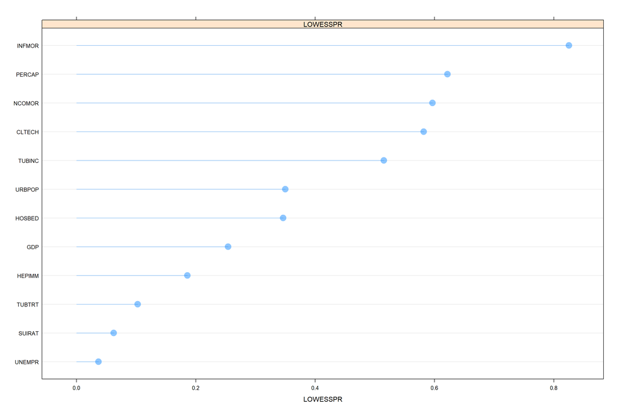

```r
##################################
# Exploring predictor performance
# using LOWESS
##################################
dotplot(Predictor ~ LOWESSPR | Metric,
        FE_LOWESSPR_Summary,
        origin = 0,
        type = c("p", "h"),
        pch = 16,
        cex = 2,
        alpha = 0.45,
        prepanel = function(x, y) {
            list(ylim = levels(reorder(y, x)))
        },
        panel = function(x, y, ...) {
            panel.dotplot(x, reorder(y, x), ...)
        })
```

#### 1.3.5.2 Pearson’s Correlation Coefficient (PCC)

**Code Chunk | Output**

```r
##################################
# Obtaining the Pearson correlation coefficient
##################################
(FE_PCC <- abs(cor(PME.Numeric, method="pearson")[-13,13]))
```

```
##     UNEMPR     INFMOR        GDP     CLTECH     PERCAP     TUBINC     HEPIMM
## 0.01518356 0.87964210 0.45844159 0.75234946 0.78523930 0.58919807 0.43149521
##     HOSBED     TUBTRT     URBPOP     NCOMOR     SUIRAT
## 0.56281916 0.32042539 0.57322144 0.73325984 0.17867507
```

```r
##################################
# Formulating the summary table
##################################
FE_PCC_Summary <- data.frame(Predictor = names(PME.Numeric)[1:(ncol(PME.Numeric)-1)],
                             PCC = FE_PCC,
                             Metric = rep("PCC", length(FE_PCC)))

FE_PCC_Summary
```

```
##        Predictor        PCC Metric
## UNEMPR    UNEMPR 0.01518356    PCC
## INFMOR    INFMOR 0.87964210    PCC
## GDP          GDP 0.45844159    PCC
## CLTECH    CLTECH 0.75234946    PCC
## PERCAP    PERCAP 0.78523930    PCC
## TUBINC    TUBINC 0.58919807    PCC
## HEPIMM    HEPIMM 0.43149521    PCC
## HOSBED    HOSBED 0.56281916    PCC
## TUBTRT    TUBTRT 0.32042539    PCC
## URBPOP    URBPOP 0.57322144    PCC
## NCOMOR    NCOMOR 0.73325984    PCC
## SUIRAT    SUIRAT 0.17867507    PCC
```

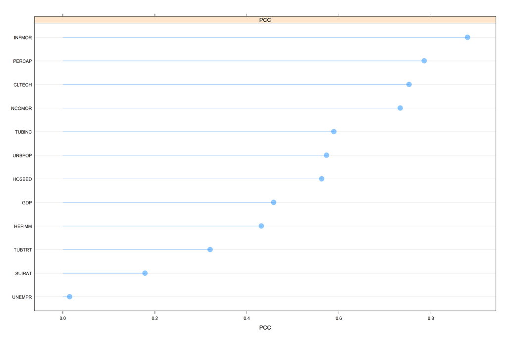

```r
##################################
# Exploring predictor performance
# using PCC
##################################
dotplot(Predictor ~ PCC | Metric,
        FE_PCC_Summary,
        origin = 0,
        type = c("p", "h"),
        pch = 16,
        cex = 2,
        alpha = 0.45,
        prepanel = function(x, y) {
            list(ylim = levels(reorder(y, x)))
        },
        panel = function(x, y, ...) {
            panel.dotplot(x, reorder(y, x), ...)
        })
```

#### 1.3.5.3 Spearman’s Rank Correlation Coefficient (SRCC)

**Code Chunk | Output**

```r
##################################
# Obtaining the Spearman's rank correlation coefficient
##################################
(FE_SRCC <- abs(cor(PME.Numeric, method="spearman")[-13,13]))
```

```
##      UNEMPR      INFMOR         GDP      CLTECH      PERCAP      TUBINC
## 0.003729075 0.891871299 0.499048543 0.783732221 0.798156088 0.716251344
##      HEPIMM      HOSBED      TUBTRT      URBPOP      NCOMOR      SUIRAT
## 0.382149849 0.555871706 0.332516893 0.600468144 0.789128052 0.124188611
```

```r
##################################
# Formulating the summary table
##################################
FE_SRCC_Summary <- data.frame(Predictor = names(PME.Numeric)[1:(ncol(PME.Numeric)-1)],
                             SRCC = FE_SRCC,
                             Metric = rep("SRCC", length(FE_SRCC)))

FE_SRCC_Summary
```

```
##        Predictor        SRCC Metric
## UNEMPR    UNEMPR 0.003729075   SRCC
## INFMOR    INFMOR 0.891871299   SRCC
## GDP          GDP 0.499048543   SRCC
## CLTECH    CLTECH 0.783732221   SRCC
## PERCAP    PERCAP 0.798156088   SRCC
## TUBINC    TUBINC 0.716251344   SRCC
## HEPIMM    HEPIMM 0.382149849   SRCC
## HOSBED    HOSBED 0.555871706   SRCC
## TUBTRT    TUBTRT 0.332516893   SRCC
## URBPOP    URBPOP 0.600468144   SRCC
## NCOMOR    NCOMOR 0.789128052   SRCC
## SUIRAT    SUIRAT 0.124188611   SRCC
```

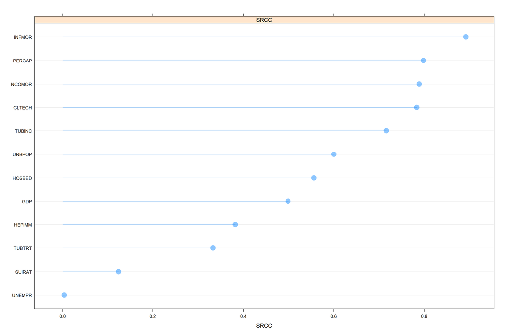

```r
##################################
# Exploring predictor performance
# using SRCC
##################################
dotplot(Predictor ~ SRCC | Metric,
        FE_SRCC_Summary,
        origin = 0,
        type = c("p", "h"),
        pch = 16,
        cex = 2,
        alpha = 0.45,
        prepanel = function(x, y) {
            list(ylim = levels(reorder(y, x)))
        },
        panel = function(x, y, ...) {
            panel.dotplot(x, reorder(y, x), ...)
        })
```

#### 1.3.5.4 Maximal Information Coefficient (MIC)

**Code Chunk | Output**

```r
##################################
# Obtaining the maximal information coefficient
##################################
FE_MIC <- mine(x = PME.Numeric[,!names(PME.Numeric) %in% c("LIFEXP")],
               y = PME$LIFEXP)$MIC

##################################
# Formulating the summary table
##################################
FE_MIC_Summary <- data.frame(Predictor = names(PME.Numeric)[1:(ncol(PME.Numeric)-1)],
                             MIC = FE_MIC[,1],
                             Metric = rep("MIC", length(FE_MIC)))

FE_MIC_Summary
```

```
##    Predictor       MIC Metric
## 1     UNEMPR 0.1911950    MIC
## 2     INFMOR 0.7083938    MIC
## 3        GDP 0.3234249    MIC
## 4     CLTECH 0.5099735    MIC
## 5     PERCAP 0.5502257    MIC
## 6     TUBINC 0.5121849    MIC
## 7     HEPIMM 0.2652364    MIC
## 8     HOSBED 0.3711493    MIC
## 9     TUBTRT 0.2356973    MIC
## 10    URBPOP 0.4097827    MIC
## 11    NCOMOR 0.6438989    MIC
## 12    SUIRAT 0.2325372    MIC
```

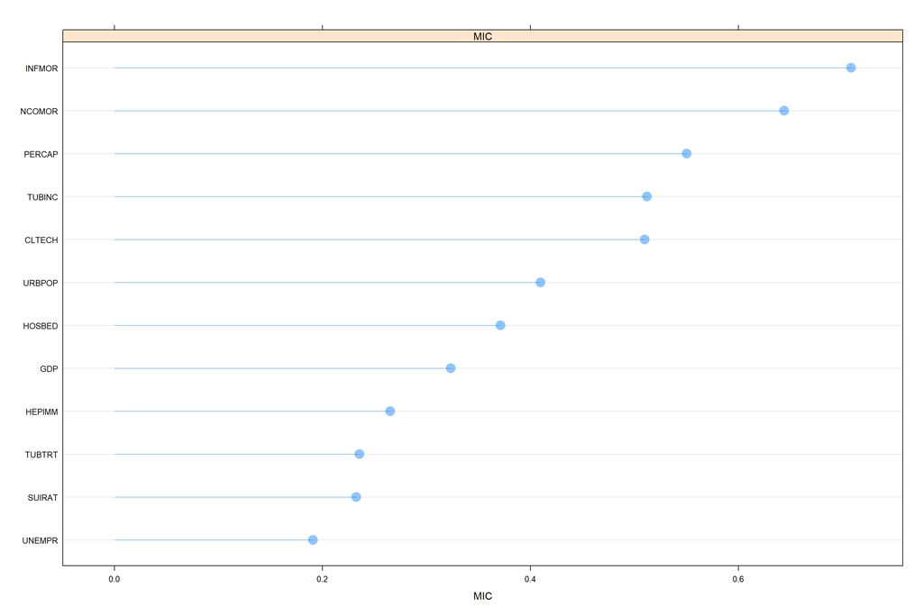

```r
##################################
# Exploring predictor performance
# using MIC
##################################
dotplot(Predictor ~ MIC | Metric,
        FE_MIC_Summary,
        origin = 0,
        type = c("p", "h"),
        pch = 16,
        cex = 2,
        alpha = 0.45,
        prepanel = function(x, y) {
            list(ylim = levels(reorder(y, x)))
        },
        panel = function(x, y, ...) {
            panel.dotplot(x, reorder(y, x), ...)
        })
```

#### 1.3.5.5 Relief Values (RV)

**Code Chunk | Output**

```r
##################################
# Obtaining the relief values
##################################
FE_RV <- attrEval(LIFEXP ~ .,
                  data = PME.Numeric,
                  estimator = "RReliefFequalK")

##################################
# Formulating the summary table
##################################
FE_RV_Summary <- data.frame(Predictor = names(FE_RV),
                            RV = FE_RV,
                            Metric = rep("RV", length(FE_RV)))

FE_RV_Summary
```

```
##        Predictor           RV Metric
## UNEMPR    UNEMPR  0.007050804     RV
## INFMOR    INFMOR  0.090032432     RV
## GDP          GDP -0.107294188     RV
## CLTECH    CLTECH  0.042070458     RV
## PERCAP    PERCAP -0.042064701     RV
## TUBINC    TUBINC  0.073890249     RV
## HEPIMM    HEPIMM -0.039606463     RV
## HOSBED    HOSBED -0.062080020     RV
## TUBTRT    TUBTRT -0.155115571     RV
## URBPOP    URBPOP -0.105766623     RV
## NCOMOR    NCOMOR  0.268209813     RV
## SUIRAT    SUIRAT  0.104271800     RV
```

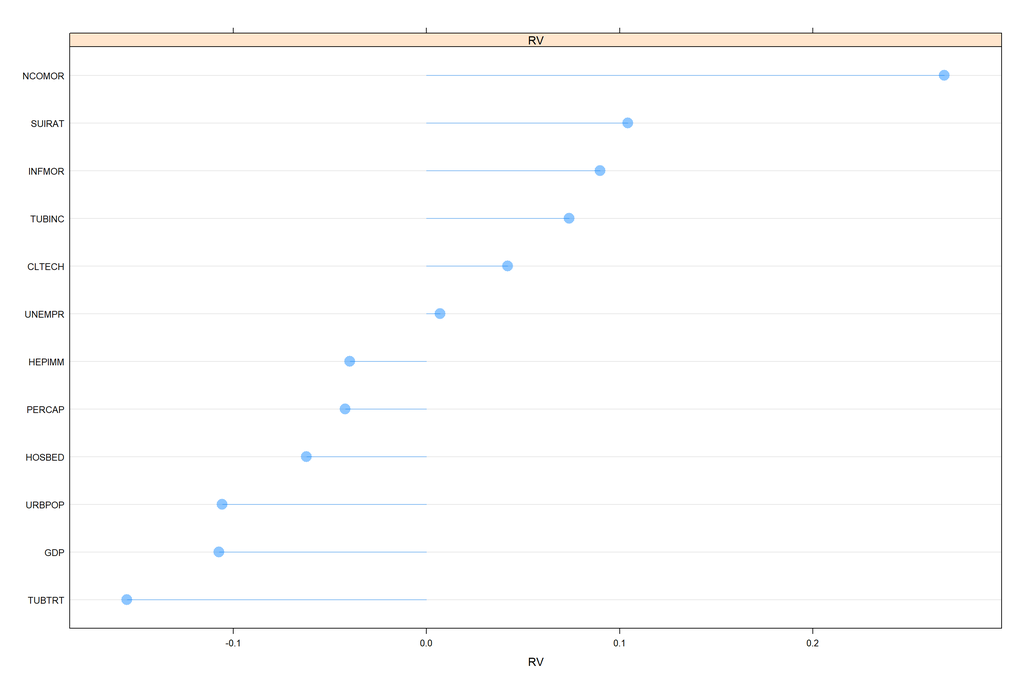

```r
##################################
# Exploring predictor performance
##################################
dotplot(Predictor ~ RV | Metric,
        FE_RV_Summary,
        origin = 0,
        type = c("p", "h"),
        pch = 16,
        cex = 2,
        alpha = 0.45,
        prepanel = function(x, y) {
            list(ylim = levels(reorder(y, x)))
        },
        panel = function(x, y, ...) {
            panel.dotplot(x, reorder(y, x), ...)
        })
```

### 1.3.6 Model Development and Performance Estimation

#### 1.3.6.1 Stochastic Gradient Boosting (GBM)

**Code Chunk | Output**

```r
##################################
# Preparing the dataset for
# model development and test
##################################
set.seed(12345678)
trainIndex <- createDataPartition(PME$LIFEXP,
                                  p = 0.8,
                                  list = FALSE,
                                  times = 1)

##################################
# Formulating the model development data
##################################
MD <- PME[ trainIndex,]

##################################
# Formulating the model test data
##################################
MT <- PME[-trainIndex,]

##################################
# Preparing the dataset for
# model development
##################################
MD <- MD[,c("GENDER","CONTIN","INFMOR","PERCAP","CLTECH","NCOMOR","LIFEXP")]

MD.Model.Predictors <- MD[,c("GENDER","CONTIN","INFMOR","PERCAP","CLTECH","NCOMOR")]

##################################
# Preparing the dataset for
# model test
##################################
MT <- MT[,c("GENDER","CONTIN","INFMOR","PERCAP","CLTECH","NCOMOR","LIFEXP")]

MT.Model.Predictors <- MT[,c("GENDER","CONTIN","INFMOR","PERCAP","CLTECH","NCOMOR")]

##################################
# Creating consistent fold assignments
# for the 10-Fold Cross Validation process
##################################
set.seed(12345678)
KFold_Indices <- createFolds(MD$LIFEXP,
                             k = 10,
                             returnTrain=TRUE)
KFold_Control <- trainControl(method="cv",
                              index=KFold_Indices)

##################################
# Defining the model hyperparameter values
# for the GBM model
##################################
GBM_Grid = expand.grid(n.trees = c(100, 200, 300),
                       interaction.depth = c(1, 3, 5),
                       shrinkage = c(0.10,0.05,0.01),
                       n.minobsinnode = c(15,10,5))

##################################
# Running the GBM model
# by setting the caret method to 'gbm'
##################################
set.seed(12345678)
GBM_Tune <- train(x = MD.Model.Predictors,
                  y = MD$LIFEXP,
                  method = "gbm",
                  tuneGrid = GBM_Grid,
                  trControl = KFold_Control)
##################################
# Reporting the cross-validation results
# for the GBM model
##################################
GBM_Tune
```

```
## Stochastic Gradient Boosting
##
## 292 samples
##   6 predictor
##
## No pre-processing
## Resampling: Cross-Validated (10 fold)
## Summary of sample sizes: 264, 263, 263, 262, 263, 264, ...
## Resampling results across tuning parameters:
##
##   shrinkage  interaction.depth  n.minobsinnode  n.trees  RMSE      Rsquared
##   0.01       1                   5              100      4.772676  0.8333691
##   0.01       1                   5              200      3.515429  0.8726404
##   0.01       1                   5              300      2.877624  0.8964547
##   0.01       1                  10              100      4.793621  0.8332069
##   0.01       1                  10              200      3.521911  0.8733517
##   0.01       1                  10              300      2.890117  0.8956765
##   0.01       1                  15              100      4.793589  0.8339653
##   0.01       1                  15              200      3.530219  0.8713678
##   0.01       1                  15              300      2.904276  0.8956071
##   0.01       3                   5              100      3.892040  0.8947209
##   0.01       3                   5              200      2.654034  0.9139912
##   0.01       3                   5              300      2.264173  0.9235081
##   0.01       3                  10              100      3.896555  0.8970888
##   0.01       3                  10              200      2.650019  0.9149851
##   0.01       3                  10              300      2.270424  0.9234616
##   0.01       3                  15              100      3.936460  0.8916345
##   0.01       3                  15              200      2.697619  0.9125729
##   0.01       3                  15              300      2.311237  0.9215290
##   0.01       5                   5              100      3.698565  0.9106552
##   0.01       5                   5              200      2.476083  0.9228052
##   0.01       5                   5              300      2.189965  0.9274235
##   0.01       5                  10              100      3.694360  0.9124533
##   0.01       5                  10              200      2.483889  0.9223152
##   0.01       5                  10              300      2.188089  0.9272777
##   0.01       5                  15              100      3.743395  0.9073428
##   0.01       5                  15              200      2.537516  0.9193448
##   0.01       5                  15              300      2.252018  0.9238906
##   0.05       1                   5              100      2.348301  0.9165106
##   0.05       1                   5              200      2.164617  0.9255460
```

[output cut: 123 more lines]

```
##   1.593423
##   1.573554
##   1.617333
##   1.630894
##   1.638725
##   1.617015
##   1.634059
##   1.649568
##   1.616787
##   1.619968
##   1.617048
##
## RMSE was used to select the optimal model using the smallest value.
## The final values used for the model were n.trees = 200, interaction.depth =
##  3, shrinkage = 0.1 and n.minobsinnode = 10.
```

```r
GBM_Tune$finalModel
```

```
## A gradient boosted model with gaussian loss function.
## 200 iterations were performed.
## There were 6 predictors of which 6 had non-zero influence.
```

```r
(GBM_Tune_RMSE <- GBM_Tune$results[GBM_Tune$results$shrinkage==GBM_Tune$bestTune$shrinkage &
                              GBM_Tune$results$interaction.depth==GBM_Tune$bestTune$interaction.depth &
                              GBM_Tune$results$n.minobsinnode==GBM_Tune$bestTune$n.minobsinnode &
                              GBM_Tune$results$n.trees==GBM_Tune$bestTune$n.trees,
                 c("RMSE")])
```

```
## [1] 2.107162
```

```r
(GBM_Tune_Rsquared <- GBM_Tune$results[GBM_Tune$results$shrinkage==GBM_Tune$bestTune$shrinkage &
                              GBM_Tune$results$interaction.depth==GBM_Tune$bestTune$interaction.depth &
                              GBM_Tune$results$n.minobsinnode==GBM_Tune$bestTune$n.minobsinnode &
                              GBM_Tune$results$n.trees==GBM_Tune$bestTune$n.trees,
                 c("Rsquared")])
```

```
## [1] 0.9285203
```

```r
(GBM_Tune_MAE <- GBM_Tune$results[GBM_Tune$results$shrinkage==GBM_Tune$bestTune$shrinkage &
                              GBM_Tune$results$interaction.depth==GBM_Tune$bestTune$interaction.depth &
                              GBM_Tune$results$n.minobsinnode==GBM_Tune$bestTune$n.minobsinnode &
                              GBM_Tune$results$n.trees==GBM_Tune$bestTune$n.trees,
                 c("MAE")])
```

```
## [1] 1.559041
```

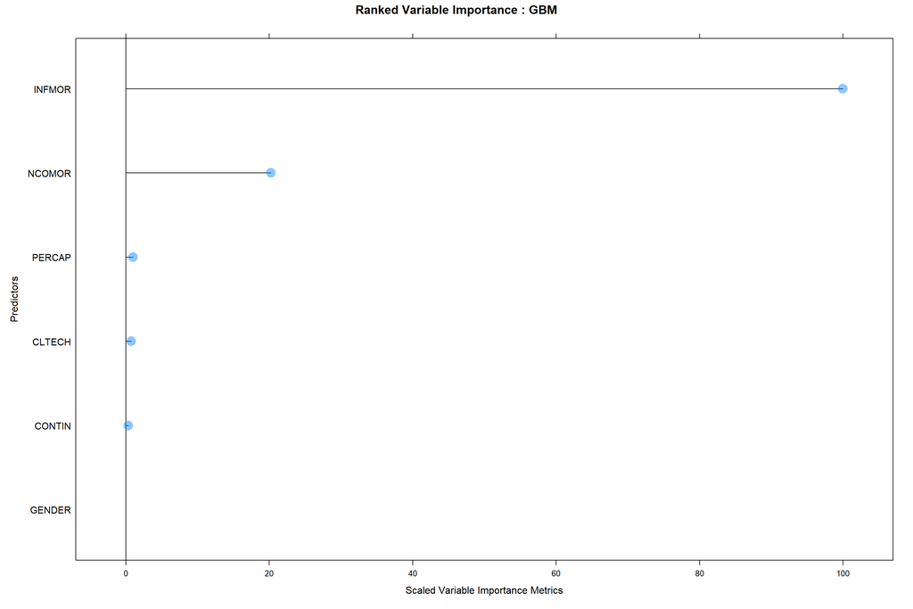

```r
##################################
# Identifying and plotting the
# best model predictors
# for the GBM model
##################################
GBM_VarImp <- varImp(GBM_Tune, scale = TRUE)
plot(GBM_VarImp,
     scales=list(y=list(cex = .95)),
     main="Ranked Variable Importance : GBM",
     xlab="Scaled Variable Importance Metrics",
     ylab="Predictors",
     cex=2,
     origin=0,
     alpha=0.45)
```

#### 1.3.6.2 Random Forest (RF)

**Code Chunk | Output**

```r
##################################
# Defining the model hyperparameter values
# for the RF model
##################################
RF_Grid = data.frame(mtry = c(100, 200, 300, 400, 500,
                              600, 700, 800, 900, 1000))

##################################
# Running the RF model
# by setting the caret method to 'RF'
##################################
set.seed(12345678)
RF_Tune <- train(x = MD.Model.Predictors,
                 y = MD$LIFEXP,
                 method = "rf",
                 tuneGrid = RF_Grid,
                 trControl = KFold_Control)

##################################
# Reporting the cross-validation results
# for the RF model
##################################
RF_Tune
```

```
## Random Forest
##
## 292 samples
##   6 predictor
##
## No pre-processing
## Resampling: Cross-Validated (10 fold)
## Summary of sample sizes: 264, 263, 263, 262, 263, 264, ...
## Resampling results across tuning parameters:
##
##   mtry  RMSE      Rsquared   MAE
##    100  2.244547  0.9196737  1.619943
##    200  2.249565  0.9196008  1.620459
##    300  2.251214  0.9194065  1.628754
##    400  2.239011  0.9201778  1.618476
##    500  2.244594  0.9199741  1.623557
##    600  2.250218  0.9195438  1.627748
##    700  2.250948  0.9195926  1.627966
##    800  2.252804  0.9194439  1.626298
##    900  2.256902  0.9191818  1.630857
##   1000  2.245525  0.9198362  1.618343
##
## RMSE was used to select the optimal model using the smallest value.
## The final value used for the model was mtry = 400.
```

```r
RF_Tune$finalModel
```

```
##
## Call:
##  randomForest(x = x, y = y, mtry = param$mtry)
##                Type of random forest: regression
##                      Number of trees: 500
## No. of variables tried at each split: 6
##
##           Mean of squared residuals: 5.126832
##                     % Var explained: 91.72
```

```r
(RF_Tune_RMSE <- RF_Tune$results[RF_Tune$results$mtry==RF_Tune$bestTune$mtry,
                 c("RMSE")])
```

```
## [1] 2.239011
```

```r
(RF_Tune_Rsquared <- RF_Tune$results[RF_Tune$results$mtry==RF_Tune$bestTune$mtry,
                 c("Rsquared")])
```

```
## [1] 0.9201778
```

```r
(RF_Tune_MAE <- RF_Tune$results[RF_Tune$results$mtry==RF_Tune$bestTune$mtry,
                 c("MAE")])
```

```
## [1] 1.618476
```

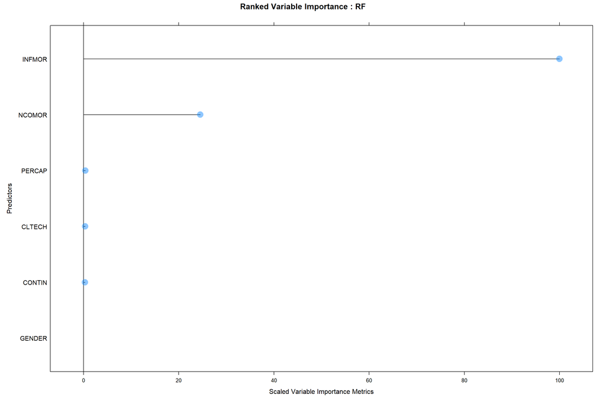

```r
##################################
# Identifying and plotting the
# best model predictors
# for the RF model
##################################
RF_VarImp <- varImp(RF_Tune, scale = TRUE)
plot(RF_VarImp,
     scales=list(y=list(cex = .95)),
     main="Ranked Variable Importance : RF",
     xlab="Scaled Variable Importance Metrics",
     ylab="Predictors",
     cex=2,
     origin=0,
     alpha=0.45)
```

#### 1.3.6.3 Neural Network (NN)

**Code Chunk | Output**

```r
##################################
# Defining the model hyperparameter values
# for the NN model
##################################
NN_Grid = expand.grid(size = c(2, 5, 10, 15, 20),
                      decay = c(0, 0.1, 0.001, 0.0001, 0.00001))

##################################
# Running the NN model
# by setting the caret method to 'NN'
##################################
set.seed(12345678)
NN_Tune <- train(x = MD.Model.Predictors,
                 y = MD$LIFEXP,
                 method = "nnet",
                 linout = TRUE,
                 preProcess = c('center', 'scale'),
                 maxit = 500,
                 tuneGrid = NN_Grid,
                 trControl = KFold_Control)
##################################
# Reporting the cross-validation results
# for the NN model
##################################
NN_Tune
```

```
## Neural Network
##
## 292 samples
##   6 predictor
##
## Pre-processing: centered (4), scaled (4), ignore (2)
## Resampling: Cross-Validated (10 fold)
## Summary of sample sizes: 264, 263, 263, 262, 263, 264, ...
## Resampling results across tuning parameters:
##
##   size  decay  RMSE      Rsquared   MAE
##    2    0e+00  2.913158  0.8500380  2.299048
##    2    1e-05  3.316750  0.7817528  2.514331
##    2    1e-04  3.312748  0.9255037  2.623476
##    2    1e-03  2.179988  0.9262000  1.649639
##    2    1e-01  2.070060  0.9321827  1.594778
##    5    0e+00  5.259886  0.8372621  2.275294
##    5    1e-05  3.641720  0.8067295  2.076761
##    5    1e-04  2.622448  0.8956273  1.750379
##    5    1e-03  2.288813  0.9148856  1.683198
##    5    1e-01  2.244542  0.9208400  1.660874
##   10    0e+00  4.090892  0.8342633  2.272149
##   10    1e-05  6.251900  0.6529587  3.162672
##   10    1e-04  3.404514  0.8251865  2.140352
##   10    1e-03  2.828581  0.8793067  2.143924
##   10    1e-01  2.323915  0.9157548  1.729951
##   15    0e+00  4.182909  0.7642496  2.918018
##   15    1e-05  4.129136  0.7596288  2.961311
##   15    1e-04  4.024271  0.7862760  2.876569
##   15    1e-03  3.610424  0.8251640  2.696243
##   15    1e-01  2.543247  0.9030396  1.909596
##   20    0e+00  4.804438  0.7226852  3.660531
##   20    1e-05  4.303982  0.7508849  3.181808
##   20    1e-04  4.909855  0.6993867  3.617313
##   20    1e-03  4.837680  0.6951049  3.487130
##   20    1e-01  2.860518  0.8768559  2.040583
##
## RMSE was used to select the optimal model using the smallest value.
## The final values used for the model were size = 2 and decay = 0.1.
```

```r
NN_Tune$finalModel
```

```
## a 10-2-1 network with 25 weights
## inputs: GENDERFemale CONTINAsia CONTINEurope CONTINNorth America CONTINOceania CONTINSouth America INFMOR PERCAP CLTECH NCOMOR
## output(s): .outcome
## options were - linear output units  decay=0.1
```

```r
(NN_Tune_RMSE <- NN_Tune$results[NN_Tune$results$size==NN_Tune$bestTune$size &
                              NN_Tune$results$decay==NN_Tune$bestTune$decay,
                 c("RMSE")])
```

```
## [1] 2.07006
```

```r
(NN_Tune_Rsquared <- NN_Tune$results[NN_Tune$results$size==NN_Tune$bestTune$size &
                              NN_Tune$results$decay==NN_Tune$bestTune$decay,
                 c("Rsquared")])
```

```
## [1] 0.9321827
```

```r
(NN_Tune_MAE <- NN_Tune$results[NN_Tune$results$size==NN_Tune$bestTune$size &
                              NN_Tune$results$decay==NN_Tune$bestTune$decay,
                 c("MAE")])
```

```
## [1] 1.594778
```

```r
##################################
# Identifying and plotting the
# best model predictors
# for the NN model
##################################
# NN_VarImp <- varImp(NN_Tune, scale = TRUE)
# plot(NN_VarImp,
#      scales=list(y=list(cex = .95)),
#      main="Ranked Variable Importance : NN",
#      xlab="Scaled Variable Importance Metrics",
#      ylab="Predictors",
#      cex=2,
#      origin=0,
#      alpha=0.45)
```

#### 1.3.6.4 Partial Least Squares Regression (PLS)

**Code Chunk | Output**

```r
##################################
# Defining the model hyperparameter values
# for the PLS model
##################################
PLS_Grid = expand.grid(ncomp = 1:5)

##################################
# Running the PLS model
# by setting the caret method to 'pls'
##################################
set.seed(12345678)
PLS_Tune <- train(x = MD.Model.Predictors,
                  y = MD$LIFEXP,
                  method = "pls",
                  tuneGrid = PLS_Grid,
                  trControl = KFold_Control)

##################################
# Reporting the cross-validation results
# for the PLS model
##################################
PLS_Tune
```

```
## Partial Least Squares
##
## 292 samples
##   6 predictor
##
## No pre-processing
## Resampling: Cross-Validated (10 fold)
## Summary of sample sizes: 264, 263, 263, 262, 263, 264, ...
## Resampling results across tuning parameters:
##
##   ncomp  RMSE      Rsquared   MAE
##   1      4.997627  0.6039633  4.073632
##   2      3.251276  0.8416354  2.478243
##   3      2.705139  0.8916091  2.067882
##   4      2.572417  0.9014321  2.006329
##   5      2.463222  0.9087387  1.954148
##
## RMSE was used to select the optimal model using the smallest value.
## The final value used for the model was ncomp = 5.
```

```r
PLS_Tune$finalModel
```

```
## Partial least squares regression , fitted with the orthogonal scores algorithm.
## Call:
## plsr(formula = .outcome ~ ., ncomp = ncomp, data = dat, method = "oscorespls")
```

```r
(PLS_Tune_RMSE <- PLS_Tune$results[PLS_Tune$results$ncomp==PLS_Tune$bestTune$ncomp,
                 c("RMSE")])
```

```
## [1] 2.463222
```

```r
(PLS_Tune_Rsquared <- PLS_Tune$results[PLS_Tune$results$ncomp==PLS_Tune$bestTune$ncomp,
                 c("Rsquared")])
```

```
## [1] 0.9087387
```

```r
(PLS_Tune_MAE <- PLS_Tune$results[PLS_Tune$results$ncomp==PLS_Tune$bestTune$ncomp,
                 c("MAE")])
```

```
## [1] 1.954148
```

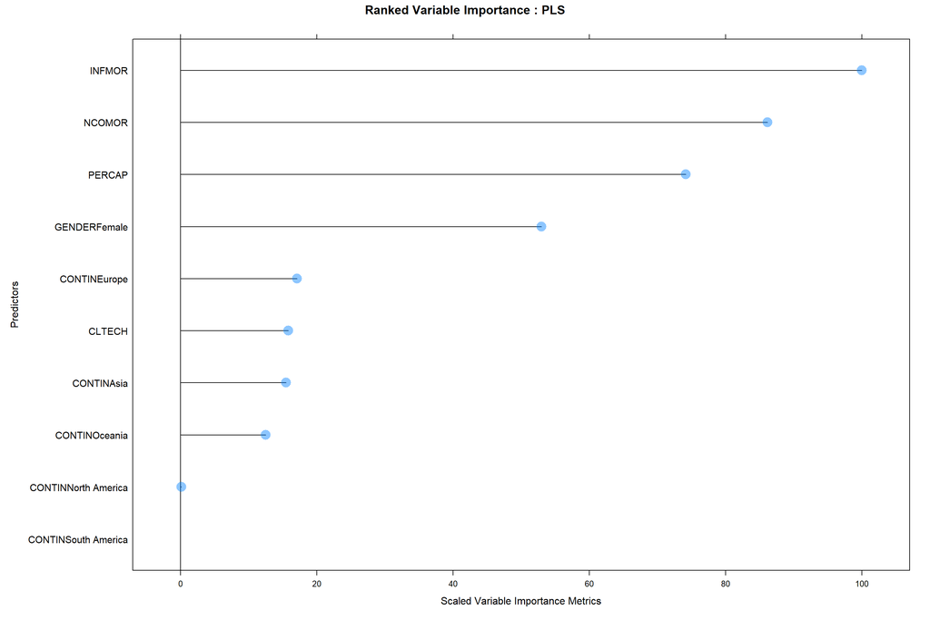

```r
##################################
# Identifying and plotting the
# best model predictors
# for the PLS model
##################################
PLS_VarImp <- varImp(PLS_Tune, scale = TRUE)
plot(PLS_VarImp,
     scales=list(y=list(cex = .95)),
     main="Ranked Variable Importance : PLS",
     xlab="Scaled Variable Importance Metrics",
     ylab="Predictors",
     cex=2,
     origin=0,
     alpha=0.45)
```

#### 1.3.6.5 Cubist Regression (CUBIST)

**Code Chunk | Output**

```r
##################################
# Defining the model hyperparameter values
# for the CUBIST model
##################################
CUBIST_Grid = expand.grid(committees = c(10, 20, 30, 40, 50),
                          neighbors = c(0, 3, 6, 9))


##################################
# Running the CUBIST model
# by setting the caret method to 'cubist'
##################################
set.seed(12345678)
CUBIST_Tune <- train(x = MD.Model.Predictors,
                   y = MD$LIFEXP,
                   method = "cubist",
                   tuneGrid = CUBIST_Grid,
                   trControl = KFold_Control)

##################################
# Reporting the cross-validation results
# for the CUBIST model
##################################
CUBIST_Tune
```

```
## Cubist
##
## 292 samples
##   6 predictor
##
## No pre-processing
## Resampling: Cross-Validated (10 fold)
## Summary of sample sizes: 264, 263, 263, 262, 263, 264, ...
## Resampling results across tuning parameters:
##
##   committees  neighbors  RMSE      Rsquared   MAE
##   10          0          2.143307  0.9284329  1.597946
##   10          3          2.161575  0.9264713  1.628394
##   10          6          2.135997  0.9293777  1.600862
##   10          9          2.120955  0.9307087  1.593085
##   20          0          2.118571  0.9293801  1.589678
##   20          3          2.171113  0.9255303  1.629055
##   20          6          2.138896  0.9287024  1.597065
##   20          9          2.118487  0.9303570  1.588802
##   30          0          2.104752  0.9307090  1.577201
##   30          3          2.171787  0.9257896  1.634946
##   30          6          2.135237  0.9293559  1.598399
##   30          9          2.113010  0.9311860  1.587534
##   40          0          2.099914  0.9312085  1.569779
##   40          3          2.164063  0.9263082  1.632470
##   40          6          2.126530  0.9299765  1.592498
##   40          9          2.104461  0.9318479  1.580217
##   50          0          2.096744  0.9316609  1.568414
##   50          3          2.158509  0.9267267  1.629668
##   50          6          2.120160  0.9304991  1.588673
##   50          9          2.097972  0.9324203  1.575005
##
## RMSE was used to select the optimal model using the smallest value.
## The final values used for the model were committees = 50 and neighbors = 0.
```

```r
CUBIST_Tune$finalModel
```

```
##
## Call:
## cubist.default(x = x, y = y, committees = param$committees)
##
## Number of samples: 292
## Number of predictors: 6
##
## Number of committees: 50
## Number of rules per committee: 6, 2, 4, 2, 4, 2, 4, 2, 4, 2, 4, 2, 4, 2, 4, 2, 4, 2, 4, 2 ...
```

```r
(CUBIST_Tune_RMSE <- CUBIST_Tune$results[CUBIST_Tune$results$committees==CUBIST_Tune$bestTune$committees &
                              CUBIST_Tune$results$neighbors==CUBIST_Tune$bestTune$neighbors,
                 c("RMSE")])
```

```
## [1] 2.096744
```

```r
(CUBIST_Tune_Rsquared <- CUBIST_Tune$results[CUBIST_Tune$results$committees==CUBIST_Tune$bestTune$committees &
                              CUBIST_Tune$results$neighbors==CUBIST_Tune$bestTune$neighbors,
                 c("Rsquared")])
```

```
## [1] 0.9316609
```

```r
(CUBIST_Tune_MAE <- CUBIST_Tune$results[CUBIST_Tune$results$committees==CUBIST_Tune$bestTune$committees &
                              CUBIST_Tune$results$neighbors==CUBIST_Tune$bestTune$neighbors,
                 c("MAE")])
```

```
## [1] 1.568414
```

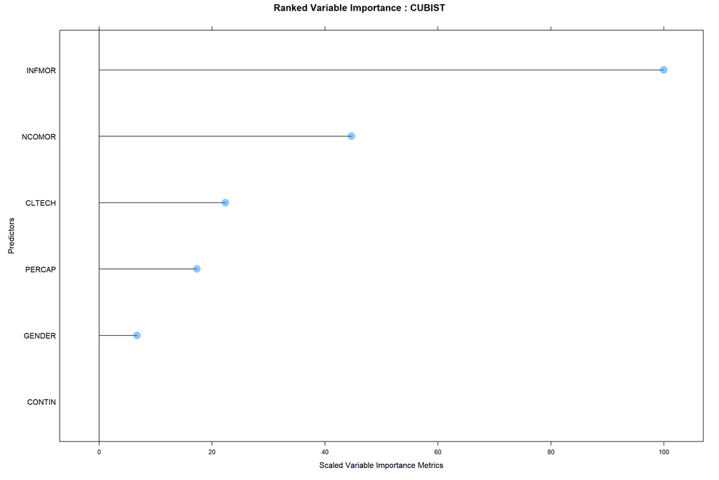

```r
##################################
# Identifying and plotting the
# best model predictors
# for the CUBIST model
##################################
CUBIST_VarImp <- varImp(CUBIST_Tune, scale = TRUE)
plot(CUBIST_VarImp,
     scales=list(y=list(cex = .95)),
     main="Ranked Variable Importance : CUBIST",
     xlab="Scaled Variable Importance Metrics",
     ylab="Predictors",
     cex=2,
     origin=0,
     alpha=0.45)
```

### 1.3.7 Model Performance Validation

**Code Chunk | Output**

```r
##################################
# Evaluating the models
# on the model test data
##################################

##################################
# Formulating the DALEX object
# for the Best GBM model
##################################
GBM_DALEX <- DALEX::explain(GBM_Tune,
                            data = MT.Model.Predictors,
                            y = MT$LIFEXP,
                            verbose = FALSE,
                            label = "GBM")

(GBM_DALEX_Performance <- model_performance(GBM_DALEX))
```

```
## Measures for:  regression
## mse        : 4.877673
## rmse       : 2.208545
## r2         : 0.9084603
## mad        : 1.155262
##
## Residuals:
##          0%         10%         20%         30%         40%         50%
## -4.35206346 -2.32130175 -1.24214793 -0.82877725 -0.46233520  0.06134295
##         60%         70%         80%         90%        100%
##  0.59630498  0.73104236  1.75812056  3.45145715  6.41897554
```

```r
(GBM_DALEX_Diagnostics <- model_diagnostics(GBM_DALEX))
```

```
##     GENDER             CONTIN       INFMOR           PERCAP
##  Male  :43   Africa       :17   Min.   :0.6419   Min.   :-1.4775
##  Female:29   Asia         :21   1st Qu.:1.7090   1st Qu.: 0.7926
##              Europe       :16   Median :2.6602   Median : 1.7266
##              North America:11   Mean   :2.5559   Mean   : 1.7439
##              Oceania      : 2   3rd Qu.:3.4135   3rd Qu.: 2.8314
##              South America: 5   Max.   :4.3858   Max.   : 4.4466
##      CLTECH           NCOMOR            y             y_hat
##  Min.   :  0.20   Min.   :2.511   Min.   :51.20   Min.   :55.11
##  1st Qu.: 49.02   1st Qu.:3.887   1st Qu.:67.42   1st Qu.:68.18
##  Median : 90.20   Median :4.742   Median :73.51   Median :73.02
##  Mean   : 72.08   Mean   :4.752   Mean   :72.61   Mean   :72.33
##  3rd Qu.:100.00   3rd Qu.:5.631   3rd Qu.:78.47   3rd Qu.:78.53
##  Max.   :100.00   Max.   :7.406   Max.   :86.20   Max.   :84.82
##    residuals        abs_residuals         label                ids
##  Min.   :-4.35206   Min.   :0.003661   Length:72          Min.   : 1.00
##  1st Qu.:-1.04139   1st Qu.:0.609636   Class :character   1st Qu.:18.75
##  Median : 0.06134   Median :1.155262   Mode  :character   Median :36.50
##  Mean   : 0.27559   Mean   :1.661957                      Mean   :36.50
##  3rd Qu.: 1.45652   3rd Qu.:2.352673                      3rd Qu.:54.25
##  Max.   : 6.41898   Max.   :6.418976                      Max.   :72.00
```

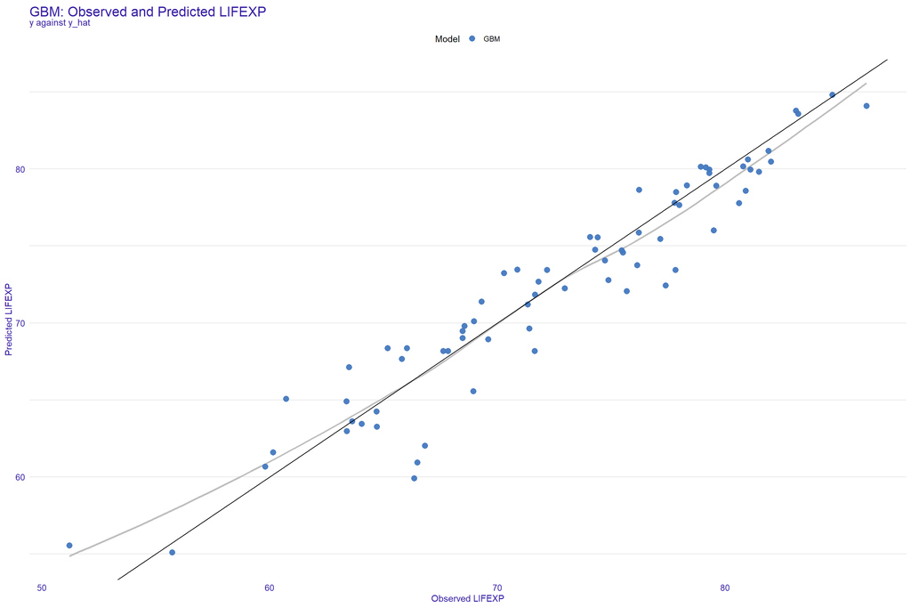

```r
plot(GBM_DALEX_Diagnostics,
     variable = "y",
     yvariable = "y_hat") +
  geom_point(size=3) +
  scale_x_continuous("Observed LIFEXP") +
  scale_y_continuous("Predicted LIFEXP") +
  geom_abline(slope = 1) +
  ggtitle("GBM: Observed and Predicted LIFEXP")
```

```r
##################################
# Formulating the DALEX object
# for the Best RF model
##################################
RF_DALEX <- DALEX::explain(RF_Tune,
                           data = MT.Model.Predictors,
                           y = MT$LIFEXP,
                           verbose = FALSE,
                           label = "RF")

(RF_DALEX_Performance <- model_performance(RF_DALEX))
```

```
## Measures for:  regression
## mse        : 6.25631
## rmse       : 2.501262
## r2         : 0.8825872
## mad        : 1.594092
##
## Residuals:
##         0%        10%        20%        30%        40%        50%        60%
## -7.2080243 -3.0176466 -2.1047296 -1.2247647 -0.2712163  0.1992440  0.7128073
##        70%        80%        90%       100%
##  1.1067986  1.7677385  3.1744799  7.4973476
```

```r
(RF_DALEX_Diagnostics <- model_diagnostics(RF_DALEX))
```

```
##     GENDER             CONTIN       INFMOR           PERCAP
##  Male  :43   Africa       :17   Min.   :0.6419   Min.   :-1.4775
##  Female:29   Asia         :21   1st Qu.:1.7090   1st Qu.: 0.7926
##              Europe       :16   Median :2.6602   Median : 1.7266
##              North America:11   Mean   :2.5559   Mean   : 1.7439
##              Oceania      : 2   3rd Qu.:3.4135   3rd Qu.: 2.8314
##              South America: 5   Max.   :4.3858   Max.   : 4.4466
##      CLTECH           NCOMOR            y             y_hat
##  Min.   :  0.20   Min.   :2.511   Min.   :51.20   Min.   :54.85
##  1st Qu.: 49.02   1st Qu.:3.887   1st Qu.:67.42   1st Qu.:68.50
##  Median : 90.20   Median :4.742   Median :73.51   Median :73.19
##  Mean   : 72.08   Mean   :4.752   Mean   :72.61   Mean   :72.58
##  3rd Qu.:100.00   3rd Qu.:5.631   3rd Qu.:78.47   3rd Qu.:78.61
##  Max.   :100.00   Max.   :7.406   Max.   :86.20   Max.   :84.60
##    residuals        abs_residuals        label                ids
##  Min.   :-7.20802   Min.   :0.01395   Length:72          Min.   : 1.00
##  1st Qu.:-1.69056   1st Qu.:0.73760   Class :character   1st Qu.:18.75
##  Median : 0.19924   Median :1.59409   Mode  :character   Median :36.50
##  Mean   : 0.02669   Mean   :1.91950                      Mean   :36.50
##  3rd Qu.: 1.50013   3rd Qu.:2.74804                      3rd Qu.:54.25
##  Max.   : 7.49735   Max.   :7.49735                      Max.   :72.00
```

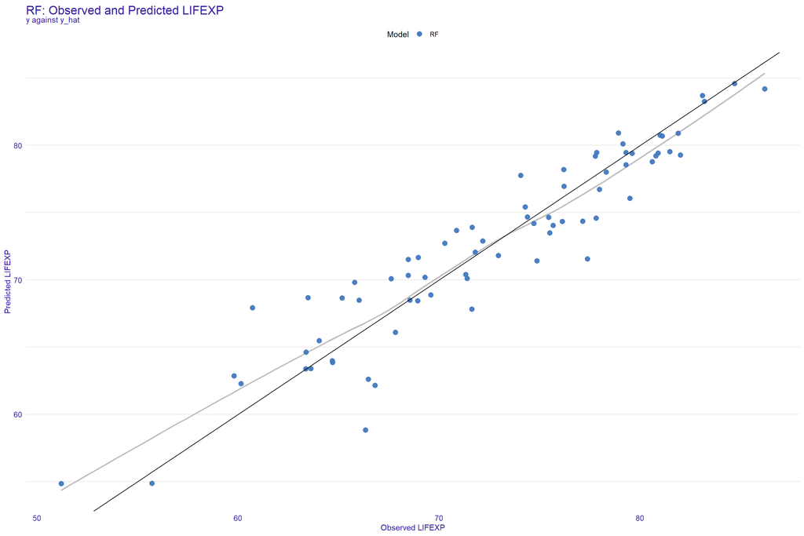

```r
plot(RF_DALEX_Diagnostics,
     variable = "y",
     yvariable = "y_hat") +
  geom_point(size=3) +
  scale_x_continuous("Observed LIFEXP") +
  scale_y_continuous("Predicted LIFEXP") +
  geom_abline(slope = 1) +
  ggtitle("RF: Observed and Predicted LIFEXP")
```

```r
##################################
# Formulating the DALEX object
# for the Best NN model
##################################
NN_DALEX <- DALEX::explain(NN_Tune,
                           data = MT.Model.Predictors,
                           y = MT$LIFEXP,
                           verbose = FALSE,
                           label = "NN")

(NN_DALEX_Performance <- model_performance(NN_DALEX))
```

```
## Measures for:  regression
## mse        : 5.300062
## rmse       : 2.302186
## r2         : 0.9005332
## mad        : 1.293056
##
## Residuals:
##         0%        10%        20%        30%        40%        50%        60%
## -6.0612264 -2.8063521 -1.3495125 -1.0121289 -0.3547678  0.2159281  0.6061218
##        70%        80%        90%       100%
##  1.1206919  1.8356939  2.8346540  7.8217567
```

```r
(NN_DALEX_Diagnostics <- model_diagnostics(NN_DALEX))
```

```
##     GENDER             CONTIN       INFMOR           PERCAP
##  Male  :43   Africa       :17   Min.   :0.6419   Min.   :-1.4775
##  Female:29   Asia         :21   1st Qu.:1.7090   1st Qu.: 0.7926
##              Europe       :16   Median :2.6602   Median : 1.7266
##              North America:11   Mean   :2.5559   Mean   : 1.7439
##              Oceania      : 2   3rd Qu.:3.4135   3rd Qu.: 2.8314
##              South America: 5   Max.   :4.3858   Max.   : 4.4466
##      CLTECH           NCOMOR            y             y_hat
##  Min.   :  0.20   Min.   :2.511   Min.   :51.20   Min.   :52.40
##  1st Qu.: 49.02   1st Qu.:3.887   1st Qu.:67.42   1st Qu.:66.97
##  Median : 90.20   Median :4.742   Median :73.51   Median :73.22
##  Mean   : 72.08   Mean   :4.752   Mean   :72.61   Mean   :72.48
##  3rd Qu.:100.00   3rd Qu.:5.631   3rd Qu.:78.47   3rd Qu.:78.83
##  Max.   :100.00   Max.   :7.406   Max.   :86.20   Max.   :84.49
##    residuals       abs_residuals        label                ids
##  Min.   :-6.0612   Min.   :0.06061   Length:72          Min.   : 1.00
##  1st Qu.:-1.2126   1st Qu.:0.72930   Class :character   1st Qu.:18.75
##  Median : 0.2159   Median :1.29306   Mode  :character   Median :36.50
##  Mean   : 0.1293   Mean   :1.77153                      Mean   :36.50
##  3rd Qu.: 1.5601   3rd Qu.:2.67075                      3rd Qu.:54.25
##  Max.   : 7.8218   Max.   :7.82176                      Max.   :72.00
```

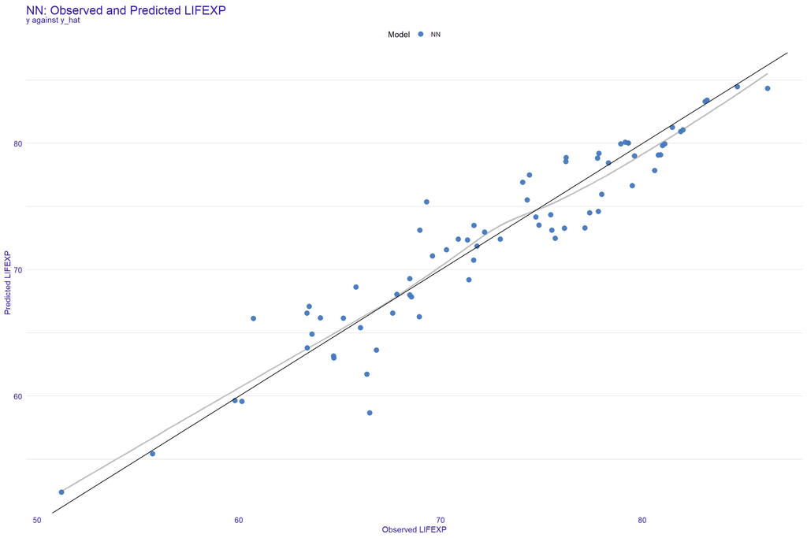

```r
plot(NN_DALEX_Diagnostics,
     variable = "y",
     yvariable = "y_hat") +
  geom_point(size=3) +
  scale_x_continuous("Observed LIFEXP") +
  scale_y_continuous("Predicted LIFEXP") +
  geom_abline(slope = 1) +
  ggtitle("NN: Observed and Predicted LIFEXP")
```

```r
##################################
# Formulating the DALEX object
# for the Best PLS model
##################################
PLS_DALEX <- DALEX::explain(PLS_Tune,
                            data = MT.Model.Predictors,
                            y = MT$LIFEXP,
                            verbose = FALSE,
                            label = "PLS")

(PLS_DALEX_Performance <- model_performance(PLS_DALEX))
```

```
## Measures for:  regression
## mse        : 7.220162
## rmse       : 2.687036
## r2         : 0.8644985
## mad        : 1.875765
##
## Residuals:
##         0%        10%        20%        30%        40%        50%        60%
## -6.7868694 -2.5089071 -1.8150301 -1.1801931 -0.4920039  0.1375484  0.7844976
##        70%        80%        90%       100%
##  2.0494752  2.6262401  3.8453344  6.0828174
```

```r
(PLS_DALEX_Diagnostics <- model_diagnostics(PLS_DALEX))
```

```
##     GENDER             CONTIN       INFMOR           PERCAP
##  Male  :43   Africa       :17   Min.   :0.6419   Min.   :-1.4775
##  Female:29   Asia         :21   1st Qu.:1.7090   1st Qu.: 0.7926
##              Europe       :16   Median :2.6602   Median : 1.7266
##              North America:11   Mean   :2.5559   Mean   : 1.7439
##              Oceania      : 2   3rd Qu.:3.4135   3rd Qu.: 2.8314
##              South America: 5   Max.   :4.3858   Max.   : 4.4466
##      CLTECH           NCOMOR            y             y_hat
##  Min.   :  0.20   Min.   :2.511   Min.   :51.20   Min.   :57.14
##  1st Qu.: 49.02   1st Qu.:3.887   1st Qu.:67.42   1st Qu.:67.18
##  Median : 90.20   Median :4.742   Median :73.51   Median :72.99
##  Mean   : 72.08   Mean   :4.752   Mean   :72.61   Mean   :72.33
##  3rd Qu.:100.00   3rd Qu.:5.631   3rd Qu.:78.47   3rd Qu.:77.39
##  Max.   :100.00   Max.   :7.406   Max.   :86.20   Max.   :84.75
##    residuals       abs_residuals        label                ids
##  Min.   :-6.7869   Min.   :0.04887   Length:72          Min.   : 1.00
##  1st Qu.:-1.4065   1st Qu.:0.82974   Class :character   1st Qu.:18.75
##  Median : 0.1375   Median :1.87576   Mode  :character   Median :36.50
##  Mean   : 0.2816   Mean   :2.15539                      Mean   :36.50
##  3rd Qu.: 2.4014   3rd Qu.:3.14434                      3rd Qu.:54.25
##  Max.   : 6.0828   Max.   :6.78687                      Max.   :72.00
```

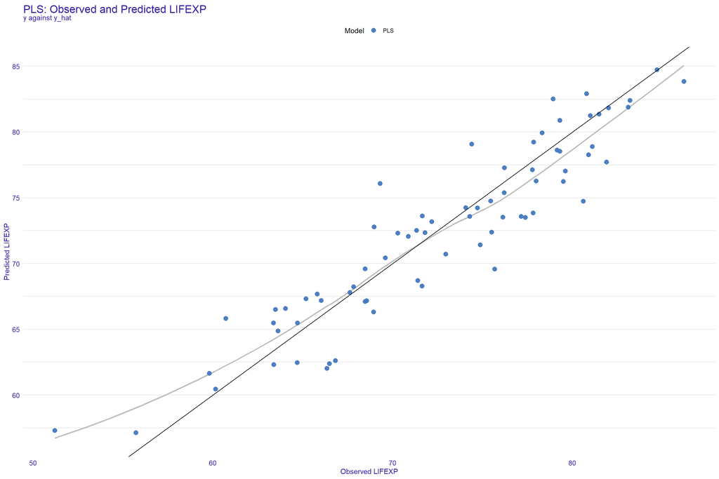

```r
plot(PLS_DALEX_Diagnostics,
     variable = "y",
     yvariable = "y_hat") +
  geom_point(size=3) +
  scale_x_continuous("Observed LIFEXP") +
  scale_y_continuous("Predicted LIFEXP") +
  geom_abline(slope = 1) +
  ggtitle("PLS: Observed and Predicted LIFEXP")
```

```r
##################################
# Formulating the DALEX object
# for the Best CUBIST model
##################################
CUBIST_DALEX <- DALEX::explain(CUBIST_Tune,
                            data = MT.Model.Predictors,
                            y = MT$LIFEXP,
                            verbose = FALSE,
                            label = "CUBIST")

(CUBIST_DALEX_Performance <- model_performance(CUBIST_DALEX))
```

```
## Measures for:  regression
## mse        : 4.955851
## rmse       : 2.226174
## r2         : 0.9069931
## mad        : 1.555514
##
## Residuals:
##          0%         10%         20%         30%         40%         50%
## -6.27483923 -2.34803998 -1.75093724 -1.08073022 -0.25740164  0.08468332
##         60%         70%         80%         90%        100%
##  0.74473043  1.16073038  1.70618640  2.84412369  5.15525385
```

```r
(CUBIST_DALEX_Diagnostics <- model_diagnostics(CUBIST_DALEX))
```

```
##     GENDER             CONTIN       INFMOR           PERCAP
##  Male  :43   Africa       :17   Min.   :0.6419   Min.   :-1.4775
##  Female:29   Asia         :21   1st Qu.:1.7090   1st Qu.: 0.7926
##              Europe       :16   Median :2.6602   Median : 1.7266
##              North America:11   Mean   :2.5559   Mean   : 1.7439
##              Oceania      : 2   3rd Qu.:3.4135   3rd Qu.: 2.8314
##              South America: 5   Max.   :4.3858   Max.   : 4.4466
##      CLTECH           NCOMOR            y             y_hat
##  Min.   :  0.20   Min.   :2.511   Min.   :51.20   Min.   :55.56
##  1st Qu.: 49.02   1st Qu.:3.887   1st Qu.:67.42   1st Qu.:67.93
##  Median : 90.20   Median :4.742   Median :73.51   Median :72.67
##  Mean   : 72.08   Mean   :4.752   Mean   :72.61   Mean   :72.49
##  3rd Qu.:100.00   3rd Qu.:5.631   3rd Qu.:78.47   3rd Qu.:77.88
##  Max.   :100.00   Max.   :7.406   Max.   :86.20   Max.   :84.71
##    residuals        abs_residuals        label                ids
##  Min.   :-6.27484   Min.   :0.01256   Length:72          Min.   : 1.00
##  1st Qu.:-1.54890   1st Qu.:0.71120   Class :character   1st Qu.:18.75
##  Median : 0.08468   Median :1.55551   Mode  :character   Median :36.50
##  Mean   : 0.11581   Mean   :1.73586                      Mean   :36.50
##  3rd Qu.: 1.40404   3rd Qu.:2.38064                      3rd Qu.:54.25
##  Max.   : 5.15525   Max.   :6.27484                      Max.   :72.00
```

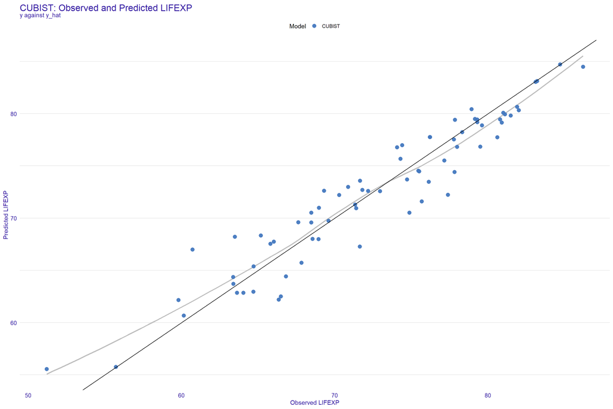

```r
plot(CUBIST_DALEX_Diagnostics,
     variable = "y",
     yvariable = "y_hat") +
  geom_point(size=3) +
  scale_x_continuous("Observed LIFEXP") +
  scale_y_continuous("Predicted LIFEXP") +
  geom_abline(slope = 1) +
  ggtitle("CUBIST: Observed and Predicted LIFEXP")
```

### 1.3.8 Model Selection

**Code Chunk | Output**

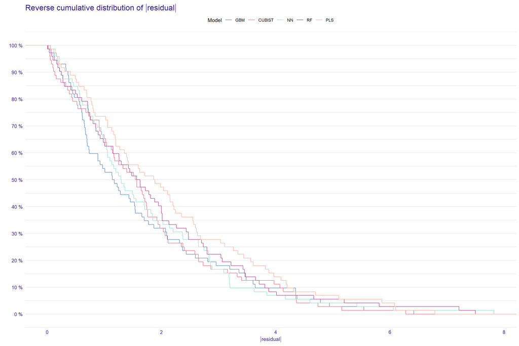

```r
##################################
# Consolidating the performance
# on the model test data
##################################
plot(GBM_DALEX_Performance,
     RF_DALEX_Performance,
     NN_DALEX_Performance,
     PLS_DALEX_Performance,
     CUBIST_DALEX_Performance)
```

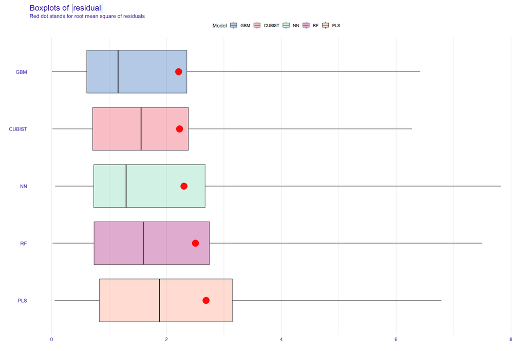

```r
plot(GBM_DALEX_Performance,
     RF_DALEX_Performance,
     NN_DALEX_Performance,
     PLS_DALEX_Performance,
     CUBIST_DALEX_Performance,
     geom = "boxplot")
```

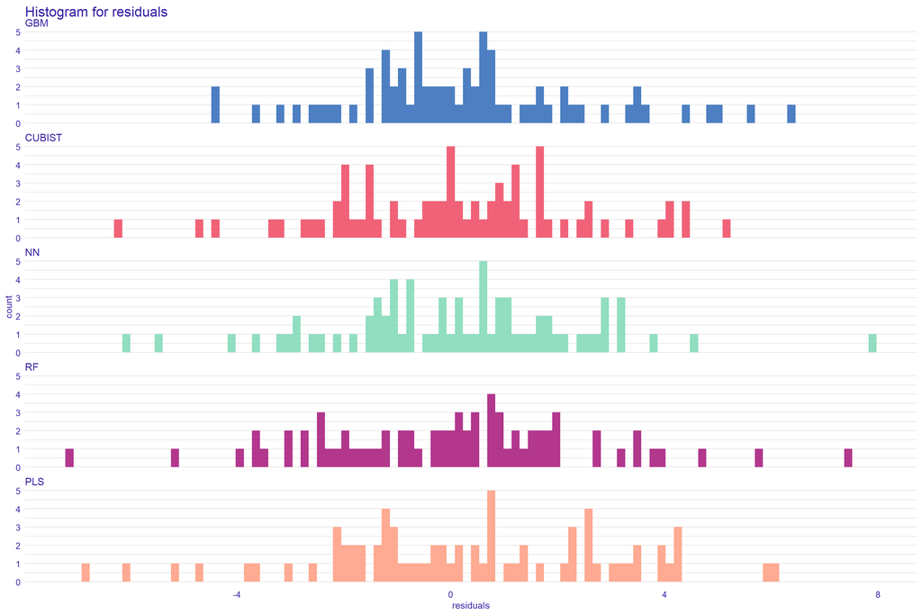

```r
plot(GBM_DALEX_Performance,
     RF_DALEX_Performance,
     NN_DALEX_Performance,
     PLS_DALEX_Performance,
     CUBIST_DALEX_Performance,
     geom = "histogram")
```

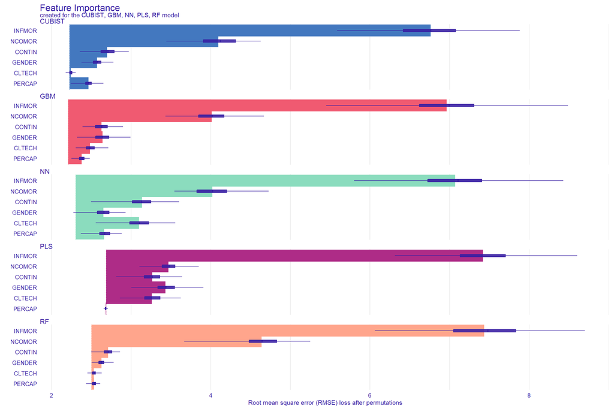

```r
##################################
# Consolidating the variable importance
# on the model test data
##################################
GBM_DALEX_VariableImportance    <- model_parts(GBM_DALEX,
                                               loss_function = loss_root_mean_square,
                                               B = 200,
                                               N = NULL)
RF_DALEX_VariableImportance     <- model_parts(RF_DALEX,
                                               loss_function = loss_root_mean_square,
                                               B = 200,
                                               N = NULL)
NN_DALEX_VariableImportance     <- model_parts(NN_DALEX,
                                               loss_function = loss_root_mean_square,
                                               B = 200,
                                               N = NULL)
PLS_DALEX_VariableImportance    <- model_parts(PLS_DALEX,
                                               loss_function = loss_root_mean_square,
                                               B = 200,
                                               N = NULL)
CUBIST_DALEX_VariableImportance <- model_parts(CUBIST_DALEX,
                                               loss_function = loss_root_mean_square,
                                               B = 200,
                                               N = NULL)

plot(GBM_DALEX_VariableImportance,
     RF_DALEX_VariableImportance,
     NN_DALEX_VariableImportance,
     PLS_DALEX_VariableImportance,
     CUBIST_DALEX_VariableImportance)
```

### 1.3.9 Model Post-Hoc Analysis

**Code Chunk | Output**

```r
# ##################################
# # Summarizing the variable importance
# # for the final model - GBM
# ##################################
# GBM_DALEX_VariableImportance
#
# plot(GBM_DALEX_VariableImportance)
#
# ##################################
# # Formulating the partial dependence plots
# # for the final model - GBM
# # using the different variables
# ##################################
# GBM_DALEX_PartialDependencePlot_INFMOR <- model_profile(GBM_DALEX,
#                                                         variables = "INFMOR")
# GBM_DALEX_PartialDependencePlot_NCOMOR <- model_profile(GBM_DALEX,
#                                                         variables = "NCOMOR")
# GBM_DALEX_PartialDependencePlot_CLTECH <- model_profile(GBM_DALEX,
#                                                         variables = "CLTECH")
# GBM_DALEX_PartialDependencePlot_PERCAP <- model_profile(GBM_DALEX,
#                                                         variables = "PERCAP")
#
# (GBM_DALEX_PDP_INFMOR <- plot(GBM_DALEX_PartialDependencePlot_INFMOR,
#                               geom = "profiles"))
# (GBM_DALEX_PDP_NCOMOR <- plot(GBM_DALEX_PartialDependencePlot_NCOMOR,
#                               geom = "profiles"))
# (GBM_DALEX_PDP_CLTECH <- plot(GBM_DALEX_PartialDependencePlot_CLTECH,
#                               geom = "profiles"))
# (GBM_DALEX_PDP_PERCAP <- plot(GBM_DALEX_PartialDependencePlot_PERCAP,
#                               geom = "profiles"))
#
# ##################################
# # Formulating the grouped partial dependence plots
# # for the final model - GBM
# # using the different variables
# ##################################
# GBM_DALEX_GroupedPartialDependencePlot_INFMOR <- model_profile(GBM_DALEX,
#                                                                variables = "INFMOR",
#                                                                groups = "GENDER")
# GBM_DALEX_GroupedPartialDependencePlot_NCOMOR <- model_profile(GBM_DALEX,
#                                                                variables = "NCOMOR",
#                                                                groups = "GENDER")
# GBM_DALEX_GroupedPartialDependencePlot_CLTECH <- model_profile(GBM_DALEX,
#                                                                variables = "CLTECH",
#                                                                groups = "GENDER")
# GBM_DALEX_GroupedPartialDependencePlot_PERCAP <- model_profile(GBM_DALEX,
#                                                                variables = "PERCAP",
#                                                                groups = "GENDER")
#
# (GBM_DALEX_GPDP_INFMOR <- plot(GBM_DALEX_GroupedPartialDependencePlot_INFMOR,
#                               geom = "profiles"))
# (GBM_DALEX_GPDP_NCOMOR <- plot(GBM_DALEX_GroupedPartialDependencePlot_NCOMOR,
#                               geom = "profiles"))
# (GBM_DALEX_GPDP_CLTECH <- plot(GBM_DALEX_GroupedPartialDependencePlot_CLTECH,
#                               geom = "profiles"))
# (GBM_DALEX_GPDP_PERCAP <- plot(GBM_DALEX_GroupedPartialDependencePlot_PERCAP,
#                               geom = "profiles"))
```

## 1.4 Summary

# **2. References**

**[Book]** [Explanatory Model Analysis: Explore, Explain, and Examine Predictive Models With examples in R and Python](https://ema.drwhy.ai/) by Przemyslaw Biecek and Tomasz Burzykowski  
**[Book]** [Explainable Machine Learning: A Guide for Making Black Box Models Explainable](https://christophm.github.io/interpretable-ml-book/) by Christoph Molnar  
**[Book]** [Explainable AI: Interpreting, Explaining and Visualizing Deep Learning](https://link.springer.com/book/10.1007/978-3-030-28954-6) by Wojciech Samek, Gregoire Montavon, Andrea Vedaldi, Lars Kai Hansen and Klaus-Robert Muller  
**[R Package]** [DALEX](https://cran.r-project.org/web/packages/DALEX/index.html) by Przemyslaw Biecek, Szymon Maksymiuk and Hubert Baniecki  
**[R Package]** [iml](https://cran.r-project.org/web/packages/iml/index.html) by Christoph Molnar  
**[R Package]** [ALEPlot](https://cran.r-project.org/web/packages/ALEPlot/index.html) by Dan Apley  
**[R Package]** [randomForest](https://cran.r-project.org/web/packages/randomForest/index.html) by Leo Breiman, Adele Cutler, Andy Liaw and Matthew Wiener  
**[R Package]** [auditor](https://cran.r-project.org/web/packages/auditor/index.html) by Alicja Gosiewska, Przemyslaw Biecek, Hubert Baniecki and Tomasz Mikołajczyk  
**[R Package]** [fastshap](https://cran.r-project.org/web/packages/fastshap/index.html) by Brandon Greenwell  
**[R Package]** [rms](https://cran.r-project.org/web/packages/rms/index.html) by Frank Harrell  
**[R Package]** [EIX](https://cran.r-project.org/web/packages/EIX/index.html) by Szymon Maksymiuk, Ewelina Karbowiak and Przemyslaw Biecek  
**[R Package]** [parsnip](https://cran.r-project.org/web/packages/parsnip/index.html) by Max Kuhn and Davis Vaughan  
**[R Package]** [h2o](https://cran.r-project.org/web/packages/h2o/index.html) by Tomas Fryda, Erin LeDell, Navdeep Gill, Spencer Aiello, Anqi Fu, Arno Candel, Cliff Click, Tom Kraljevic, Tomas Nykodym, Patrick Aboyoun, Michal Kurka, Michal Malohlava, Sebastien Poirier and Wendy Wong  
**[R Package]** [tidymodels](https://cran.r-project.org/web/packages/tidymodels/index.html) by Max Kuhn and Hadley Wickham  
**[R Package]** [e1071](https://cran.r-project.org/web/packages/e1071/index.html) by David Meyer, Evgenia Dimitriadou, Kurt Hornik, Andreas Weingessel and Friedrich Leisch  
**[R Package]** [lime](https://cran.r-project.org/web/packages/lime/index.html) by Emil Hvitfeldt, Thomas Lin Pedersen and Michael Benesty  
**[R Package]** [ExplainPrediction](https://cran.r-project.org/web/packages/ExplainPrediction/index.html) by Marko Robnik-Sikonja  
**[R Package]** [localModel](https://cran.r-project.org/web/packages/localModel/index.html) by Przemyslaw Biecek and Mateusz Staniak  
**[R Package]** [skimr](https://cran.r-project.org/web/packages/skimr/skimr.pdf) by Elin Waring  
**[R Package]** [corrplot](https://cran.r-project.org/web/packages/corrplot/corrplot.pdf) by Taiyun Wei  
**[R Package]** [lares](https://cran.rstudio.com/web/packages/lares/lares.pdf) by Bernardo Lares  
**[R Package]** [minerva](https://cran.r-project.org/web/packages/minerva/minerva.pdf) by Michele Filosi  
**[R Package]** [CORElearn](https://cran.r-project.org/web/packages/CORElearn/CORElearn.pdf) by Marko Robnik-Sikonja and Petr Savicky  
**[R Package]** [caret](https://topepo.github.io/caret/index.html) by Max Kuhn  
**[R Package]** [gbm](https://cran.r-project.org/web/packages/gbm/index.html) by Brandon Greenwell, Bradley Boehmke, Jay Cunningham and GBM Developers  
**[R Package]** [randomForest](https://cran.r-project.org/web/packages/randomForest/randomForest.pdf) by Andy Liaw  
**[R Package]** [nnet](https://cran.r-project.org/web/packages/nnet/nnet.pdf) by Brian Ripley  
**[R Package]** [pls](https://cran.r-project.org/web/packages/pls/pls.pdf) by Kristian Hovde Liland  
**[R Package]** [Cubist](https://cran.r-project.org/web/packages/Cubist/Cubist.pdf) by Max Kuhn  
**[R Package]** [patchwork](https://cran.r-project.org/web/packages/patchwork/patchwork.pdf) by Thomas Lin Pedersen  
**[Article]** [Interpretation Methods for Black-Box Machine Learning Models in Insurance Rating-Type Applications](https://support.sas.com/resources/papers/proceedings20/5116-2020.pdf) by Gabe Taylor, Sunish Menon, Huimin Ru, Ray Wright, Xin Hunt and Ralph Abbey  
**[Article]** [4 Model-Agnostic Interpretability Techniques for Complex Models](https://blogs.sas.com/content/subconsciousmusings/2020/05/07/model-agnostic-interpretability/) by Funda Gunes  
**[Article]** [How Can We Provide Post-Hoc Explanations for Black-Box AI Models?](https://aisingapore.github.io/ai-practitioner-handbook/book/6-modelling/post-hoc-explanation.html) by Joy Lin  
**[Publication]** [A Survey of Methods for Explaining Black Box Models](https://dl.acm.org/doi/10.1145/3236009) by Riccardo Guidotti, Anna Monreale, Salvatore Ruggieri, Franco Turini, Fosca Giannotti and Dino Pedreschi (ACM Computing Surveys)  
**[Publication]** [iml: An R package for Interpretable Machine Learning](https://doi.org/10.21105/joss.00786) by Christoph Molnar (Journal of Open Source Software)